# Simulação de Intervalos de Confiança

CC0290 Modelos de Regressão I - Trabalho 02

Authors

Antônio Arthur Silva de Lima

Francisco Gustavo Braga Batista

Romulo Barros de Freitas

# Intervalos de Confiança para $β1$

A estatística $T0$ segue uma distribuição t-Student com $(n−2)$ graus de liberdade, e é utilizada para a construção de intervalos de confiança pra o parâmetro $β1$ no modelo de regressão linear simples:

## Observações

- $T0$ é simétrica em torno da origem, portanto, os $IC′s$ definidos possuem o menor comprimento possível;
- Para um tamanho de amostra grande $(n→∞)$, podemos trocar $t(1−α/2;n−2)$ por $z(1−α/2)$.
- Se a normalidade de $β^1$ não se verificar, o IC é válido apenas assintoticamente **(TCL)**.

Supondo que os valores observados sejam normal e independentemente distribuídos **(iid)**, um intervalo de confiança de 100(1 - $α$ )% para o coeficiente de inclinação $β1$ no modelo de regressão linear simples é:

# Simulação

```r
# semente para a geração de números
set.seed(0)

# base de dados
dados = iris
```

```r
#modelo de regressão linear simples
m = lm(iris$Petal.Width ~ iris$Sepal.Length); summary(m)
```

```
Call:
lm(formula = iris$Petal.Width ~ iris$Sepal.Length)

Residuals:
     Min       1Q   Median       3Q      Max
-0.96671 -0.35936 -0.01787  0.28388  1.23329

Coefficients:
                  Estimate Std. Error t value Pr(>|t|)
(Intercept)       -3.20022    0.25689  -12.46   <2e-16 ***
iris$Sepal.Length  0.75292    0.04353   17.30   <2e-16 ***
---
Signif. codes:  0 '***' 0.001 '**' 0.01 '*' 0.05 '.' 0.1 ' ' 1

Residual standard error: 0.44 on 148 degrees of freedom
Multiple R-squared:  0.669, Adjusted R-squared:  0.6668
F-statistic: 299.2 on 1 and 148 DF,  p-value: < 2.2e-16
```

## Calculando o Quadrado Médio Residual:

```r
resp = dados$Petal.Width; exp = dados$Sepal.Length
Qmres = (sum((resp - mean(resp))^2) - sum((exp - mean(exp))*resp)^2/sum((exp - mean(exp))^2))/(length(exp)-2); Qmres
```

```
[1] 0.1935963
```

## Gerando 100 amostras de tamanho 30:

```r
amostras = c()
for(i in 1:100){
  amostras[i] = list(sample(dados$Sepal.Length, 30, replace = T))
}
```

## Função para calcular os estimadores de $β1$ e o $QMRes$ para cada amostra, dado um $Yi$ normal com os parâmetros anteriores:

```r
calculo = function(x){
  x = unlist(x)
  xb = mean(x); Sxx = sum((x - xb)^2)
  y = rnorm(30, m$coe[1]+m$coe[2]*x, Qmres*(1/length(x) + (x - xb)^2/Sxx))
  yb = mean(y); Syy = sum((y -yb)^2); Sxy = sum((x - xb)*y)
  QMRes = (Syy - Sxy^2/Sxx)/(length(x)-2)
  beta1_est = Sxy/Sxx
  erro = sqrt(QMRes/Sxx)
  return(c(beta1_est, erro))
}
```

```r
# testando para uma única amostra
calculo(amostras[1])
```

```
[1] 0.755743331 0.002040678
```

```r
# t(1-alfa/2, n-2), pois a hipótese considerada é bilateral, com alfa = 5%
t = qt(1-0.05/2,28); t
```

```
[1] 2.048407
```

```r
# cnstruindo os intervalos
intervalos = c()
for(i in 1:100){
  intervalos[i] = list(round(calculo(amostras[i])[1]+c(-1,1)*t*calculo(amostras[i])[2], 3))
}
```

## Visualização Gráfica

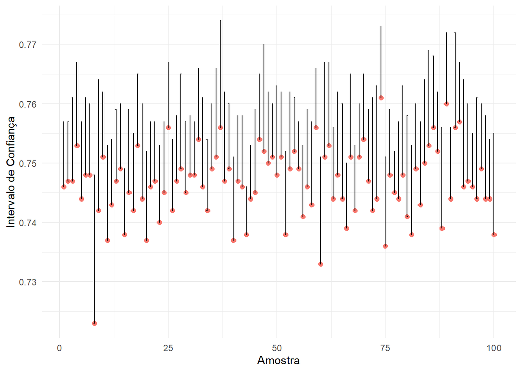

```r
# plotando os intervalos de confiança:
library(ggplot2)
ic_df <- data.frame(
  Amostra = 1:100,
  li = unlist(lapply(intervalos, function(x) x[1])),
  ls = unlist(lapply(intervalos, function(x) x[2]))
)

ggplot(ic_df, aes(x = Amostra, y = li)) +
  geom_point(aes(color = "Intervalo de Confiança"), size = 2) +
  geom_errorbar(aes(ymin = li, ymax = ls), width = 0.2) +
  labs(x = "Amostra", y = "Intervalo de Confiança") +
  theme_minimal() +
  theme(legend.position = "none")
```

# Conclusões

É importante notar que os intervalos que construímos são bilaterais, isso significa que consideramos a possibilidade de que o valor verdadeiro de $β1$ esteja tanto acima quanto abaixo do intervalo observado. No entanto, devido ao tamanho relativamente pequeno das amostras (30 itens), a precisão dos estimadores intervalares pode não ser tão alta quanto a obtida em tamanhos de amostra maiores, como +100 ou +1000.

Portanto, ao interpretar esses resultados, é fundamental reconhecer que a precisão dos intervalos de confiança está relacionada ao tamanho amostral e à natureza bilateral dos intervalos. Essas considerações devem ser levadas em conta ao aplicar esses resultados em diferentes contextos de análise de dados.